# STAA 577: Laboratory Eight Tree-based Methods (`tidyverse`)

Adapted by Tavener & Field From: James, Witten, Hastie and Tibshirani

12 December 2018

### Load necessary libraries

```r
options(warnPartialMatchArgs = FALSE)  # don't want these warnings
library(ISLR)         # The `Carseats` data set
library(MASS)         # The `Boston` data set
library(magrittr)     # pipes
library(tibble)       # tibbles
library(dplyr)        # data wrangling
library(purrr)        # iteration
library(yardstick)    # classification performance measures
library(rpart)        # building classification trees
library(randomForest) # package name says it
library(gbm)          # Boosting algorithms
library(ggplot2)      # tidy plotting
library(gridExtra)    # arranging ggplot `grobs` into grid
library(caret)        # classification and Regression Training (CV)
```

# 1 The `Carseats` Data Set

```r
Carseats %<>% tibble::as.tibble()
Carseats
```

|  | Sales | CompPrice | Income | Advertising | Population | Price | ShelveLoc | Age | Education | Urban | US |
| --- | --- | --- | --- | --- | --- | --- | --- | --- | --- | --- | --- |
| 1 | 9.50 | 138 | 73 | 11 | 276 | 120 | Bad | 42 | 17 | Yes | Yes |
| 2 | 11.22 | 111 | 48 | 16 | 260 | 83 | Good | 65 | 10 | Yes | Yes |
| 3 | 10.06 | 113 | 35 | 10 | 269 | 80 | Medium | 59 | 12 | Yes | Yes |
| 4 | 7.40 | 117 | 100 | 4 | 466 | 97 | Medium | 55 | 14 | Yes | Yes |
| 5 | 4.15 | 141 | 64 | 3 | 340 | 128 | Bad | 38 | 13 | Yes | No |
| 6 | 10.81 | 124 | 113 | 13 | 501 | 72 | Bad | 78 | 16 | No | Yes |
| 7 | 6.63 | 115 | 105 | 0 | 45 | 108 | Medium | 71 | 15 | Yes | No |
| 8 | 11.85 | 136 | 81 | 15 | 425 | 120 | Good | 67 | 10 | Yes | Yes |
| 9 | 6.54 | 132 | 110 | 0 | 108 | 124 | Medium | 76 | 10 | No | No |
| 10 | 4.69 | 132 | 113 | 0 | 131 | 124 | Medium | 76 | 17 | No | Yes |

[output cut: 390 more lines]

```r
dim(Carseats)
```

```
[1] 400  11
```

# 2 Classification Trees

**NOTE**: In this lab we will use the `rpart::rpart()` function instead of the `tree::tree()` function used in the ISLR textbook uses, since `rpart` has gained popularity over `tree` in the years since ISLR was published. `rpart` uses “recursive partitioning” to build its trees (see “Classification and Regression Trees”, by Breiman, Friedman, Olshen and Stone, 1984). Experience has shown this results in a *slight* performance improvement for classification problems compared to `tree::tree()`, although performance is similar in *this* data problem. See rpart.pdf

First we fit a general classification tree to the `Carseats` data set:

```r
# Create a variable for classification of "low" and "high" sales based on sales cutoff of 8.0
# Append new categorical variable to the Carseats dataframe
# Ensure the response variable (High) is a factor for rpart::rpart
Carseats %<>% dplyr::mutate(High = ifelse(Sales <= 8, "No", "Yes") %>% factor(),
                            # `id` is for tracking samples below; train/test
                            id  = dplyr::row_number())
Carseats
```

| Sales | CompPrice | Income | Advertising | Population | Price | ShelveLoc | Age | Education | Urban | US | High | id |
| --- | --- | --- | --- | --- | --- | --- | --- | --- | --- | --- | --- | --- |
| 9.50 | 138 | 73 | 11 | 276 | 120 | Bad | 42 | 17 | Yes | Yes | Yes | 1 |
| 11.22 | 111 | 48 | 16 | 260 | 83 | Good | 65 | 10 | Yes | Yes | Yes | 2 |
| 10.06 | 113 | 35 | 10 | 269 | 80 | Medium | 59 | 12 | Yes | Yes | Yes | 3 |
| 7.40 | 117 | 100 | 4 | 466 | 97 | Medium | 55 | 14 | Yes | Yes | No | 4 |
| 4.15 | 141 | 64 | 3 | 340 | 128 | Bad | 38 | 13 | Yes | No | No | 5 |
| 10.81 | 124 | 113 | 13 | 501 | 72 | Bad | 78 | 16 | No | Yes | Yes | 6 |
| 6.63 | 115 | 105 | 0 | 45 | 108 | Medium | 71 | 15 | Yes | No | No | 7 |
| 11.85 | 136 | 81 | 15 | 425 | 120 | Good | 67 | 10 | Yes | Yes | Yes | 8 |
| 6.54 | 132 | 110 | 0 | 108 | 124 | Medium | 76 | 10 | No | No | No | 9 |
| 4.69 | 132 | 113 | 0 | 131 | 124 | Medium | 76 | 17 | No | Yes | No | 10 |

[output cut: 390 more lines]

```r
dim(Carseats)
```

```
[1] 400  13
```

```r
tree_carseats <- rpart::rpart(High ~ .,
                              data = dplyr::select(Carseats, -Sales, -id))
tree_carseats
```

```
n= 400

node), split, n, loss, yval, (yprob)
      * denotes terminal node

  1) root 400 164 No (0.59000000 0.41000000)
    2) ShelveLoc=Bad,Medium 315  98 No (0.68888889 0.31111111)
      4) Price>=92.5 269  66 No (0.75464684 0.24535316)
        8) Advertising< 13.5 224  41 No (0.81696429 0.18303571)
         16) CompPrice< 124.5 96   6 No (0.93750000 0.06250000) *
         17) CompPrice>=124.5 128  35 No (0.72656250 0.27343750)
           34) Price>=109.5 107  20 No (0.81308411 0.18691589)
             68) Price>=126.5 65   6 No (0.90769231 0.09230769) *
             69) Price< 126.5 42  14 No (0.66666667 0.33333333)
              138) Age>=49.5 22   2 No (0.90909091 0.09090909) *
              139) Age< 49.5 20   8 Yes (0.40000000 0.60000000) *
           35) Price< 109.5 21   6 Yes (0.28571429 0.71428571) *
        9) Advertising>=13.5 45  20 Yes (0.44444444 0.55555556)
         18) Age>=54.5 20   5 No (0.75000000 0.25000000) *
         19) Age< 54.5 25   5 Yes (0.20000000 0.80000000) *
      5) Price< 92.5 46  14 Yes (0.30434783 0.69565217)
       10) Income< 57 10   3 No (0.70000000 0.30000000) *
       11) Income>=57 36   7 Yes (0.19444444 0.80555556) *
    3) ShelveLoc=Good 85  19 Yes (0.22352941 0.77647059)
      6) Price>=142.5 12   3 No (0.75000000 0.25000000) *
      7) Price< 142.5 73  10 Yes (0.13698630 0.86301370) *
```

```r
#printcp(tree_carseats)

# creates an empty plot to which we will add text of the tree
par(xpd = NA)                       # the default plot cuts off margins; enlarge
plot(tree_carseats, uniform = TRUE) # branch length equal; unrelated to gini
text(tree_carseats, use.n = TRUE, cex = 0.8)   # add text labels
```

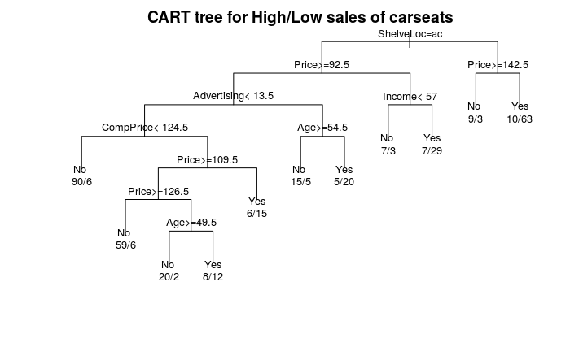

```r
title(main = "CART tree for High/Low sales of carseats")  # add title
```

```r
# Exercise: Include Sales as a predictor. What do you think will happen?
tree_carseats_trivial <- rpart::rpart(High ~ ., Carseats)
tree_carseats_trivial
printcp(tree_carseats_trivial)
plot(tree_carseats_trivial, uniform = TRUE)  # uniform vertical spacing of nodes
text(tree_carseats_trivial)
title(main = "CART tree for High/Low sales of carseats")
```

## 2.1 Estimating the test error (by hand)

Evaluate performance based on a hold-out test set.

```r
set.seed(2)                                   # reproducible
train_car <- Carseats %>%
  dplyr::sample_frac(size = 0.5)              # random selection of rows @ 50% = 200
test <- Carseats %>%
  dplyr::anti_join(train_car, by = "id") %>%  # use anti_join to get the sample setdiff
  dplyr::select(-Sales, -id)                  # remove Sales and merge identifier
train_car %<>% dplyr::select(-Sales, -id)     # remove from training also

tree_carseats <- rpart::rpart(High ~ ., data = train_car)

# set up a `tibble` containing `truth` and `predictions`:
tree_pred     <- tibble::tibble(High = test$High,
                                pred = predict(tree_carseats,
                                               newdata = test,
                                               type = "class"))
tree_pred
```

| High | pred |
| --- | --- |
| Yes | No |
| Yes | Yes |
| No | No |
| No | No |
| No | No |
| Yes | Yes |
| No | No |
| Yes | Yes |
| Yes | No |
| Yes | Yes |

[output cut: 190 more lines]

```r
# Get performance metrics via `yardstick`
tree_pred %>% yardstick::conf_mat(truth = High, estimate = pred)  # confusion
```

```
          Truth
Prediction No Yes
       No  90  20
       Yes 26  64
```

```r
tree_pred %>% yardstick::accuracy(truth = High, estimate = pred) %>% # accuracy
  purrr::pluck(".estimate")
```

```
[1] 0.77
```

```r
tree_pred %>% yardstick::sens(truth = High, estimate = pred) %>%  # sensitivity
  purrr::pluck(".estimate")
```

```
[1] 0.7758621
```

```r
tree_pred %>% yardstick::spec(truth = High, estimate = pred) %>%  # specificity
  purrr::pluck(".estimate")
```

```
[1] 0.7619048
```

## 2.2 Cross-validating trees

Cross-validation based on *misclassification* is performed “under-the-hood” within `rpart`; we simply need to access it.

Complexity parameter. Any split that does not decrease the overall lack of fit by a factor of `cp` is not attempted. For instance, with anova splitting, this means that the overall R-squared must increase by `cp` at each step. The main role of this parameter is to save computing time by pruning off splits that are obviously not worthwhile. Essentially,the user informs the program that any split which does not improve the fit by `cp` will likely be pruned off by cross-validation, and that hence the program need not pursue it.

Complexity penalties are actually ranges, not values. By default, the geometric mean of each interval is used for cross validation.

```r
rpart::printcp(tree_carseats)  # print cross-validation results
```

```
Classification tree:
rpart::rpart(formula = High ~ ., data = train_car)

Variables actually used in tree construction:
[1] Advertising Age         CompPrice   Price       ShelveLoc

Root node error: 80/200 = 0.4

n= 200

        CP nsplit rel error xerror     xstd
1 0.287500      0    1.0000  1.000 0.086603
2 0.100000      1    0.7125  0.800 0.082462
3 0.062500      2    0.6125  0.800 0.082462
4 0.050000      3    0.5500  0.775 0.081758
5 0.020833      4    0.5000  0.650 0.077540
6 0.010000      7    0.4375  0.625 0.076547
```

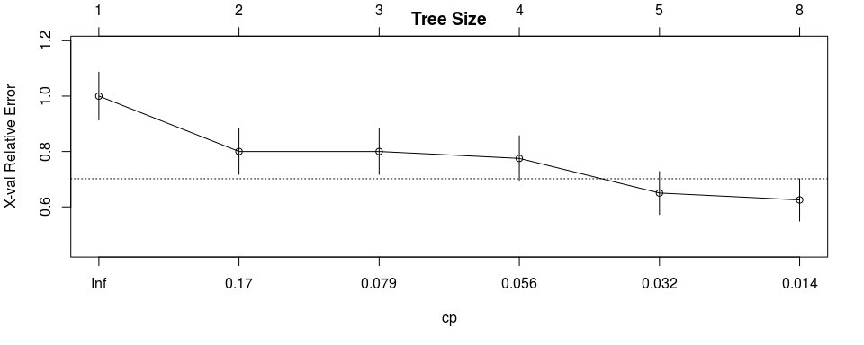

```r
rpart::plotcp(tree_carseats)   # plot cross-validation results
title("Tree Size")
```

```r
# Determine the size of the complexity parameter which minimizes cv error
# tree_carseats$cptable
best_cp <- tree_carseats$cptable %>%
  data.frame() %>%                      # easier to work with than matrices
  dplyr::slice(which.min(.$xerror)) %>% # get the row where `xerror` is min
  dplyr::pull("CP")                     # pull out `CP` from that row

best_cp
```

```
[1] 0.01
```